# Trees

MATH-7360 Data Analysis

Dr. Xiang Ji @ Tulane University

Dec 6, 2021

## Announcement

- Course evaluations (6/19)
- Remember to submit your mid-term project report to GitHub.
  - I will read them later today
  - I was going to read them last weekend if all of them were there…
- Lab 11 is optional
  - If you were able to get TensorFlow and Keras to run with python, consider trying the lab out in python
    - https://www.tensorflow.org/datasets/keras_example
  - After all, we are doing API calls to the underlying C++ TensorFlow library.
    - https://keras.io/api/
    - https://tensorflow.rstudio.com/reference/keras/
  - For M1 mac users, sorry I gave up on trying
- Presentations will be on zoom starting this Friday
  - link: https://tulane.zoom.us/j/91892909048?pwd=YUkxdHErUVkwOG83dU82QXNEUm52dz09
  - more flexible for this long semester
  - will send the same link again on Thursday
  - illustrate your project to your peers
  - Do not assume people ever read your paper
- Go over HW3 keys on Wednesday?

## Acknowledgement

Extending the linear model with R chapter 16

## Air pollution data

We apply regression tree methodology to study the relationship between atmospheric ozone concentration and meteorology in Los Angeles area in 1976. The response is Ozone ($O_3$), the atmospheric ozone concentration on a particular day. First, take a look over the data:

```r
library(faraway)
library(tidyverse)
```

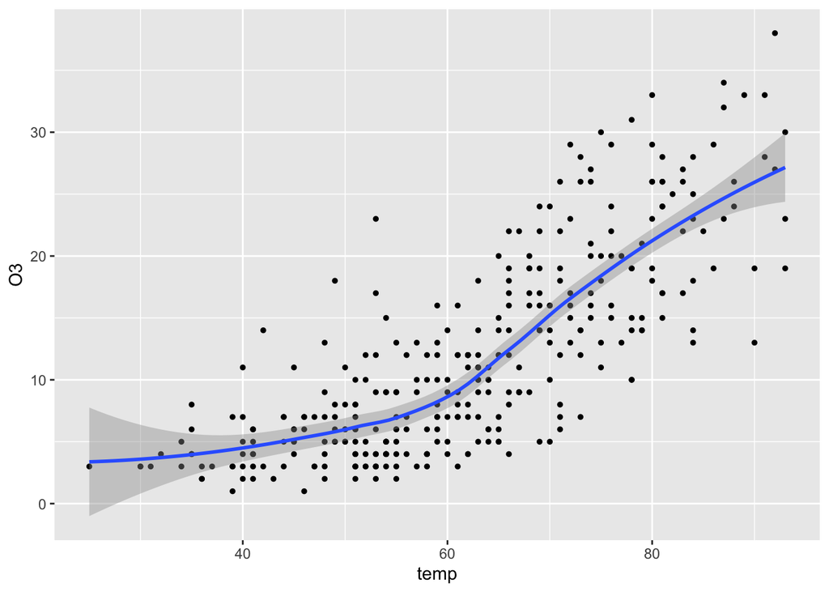

```r
ozone %>%
  ggplot(mapping = aes(x=temp, y=O3)) +
  geom_point(size=1) +
  geom_smooth()
```

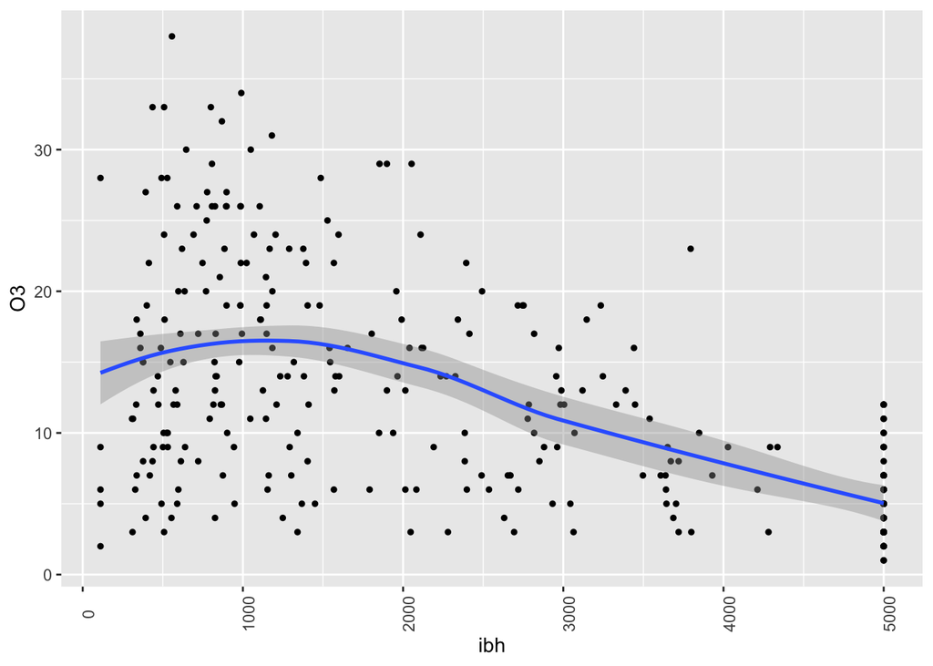

```r
ozone %>%
  ggplot(aes(x=ibh, y=O3)) +
  geom_point(size=1) +
  geom_smooth() +
  theme(axis.text.x = element_text(angle = 90))
```

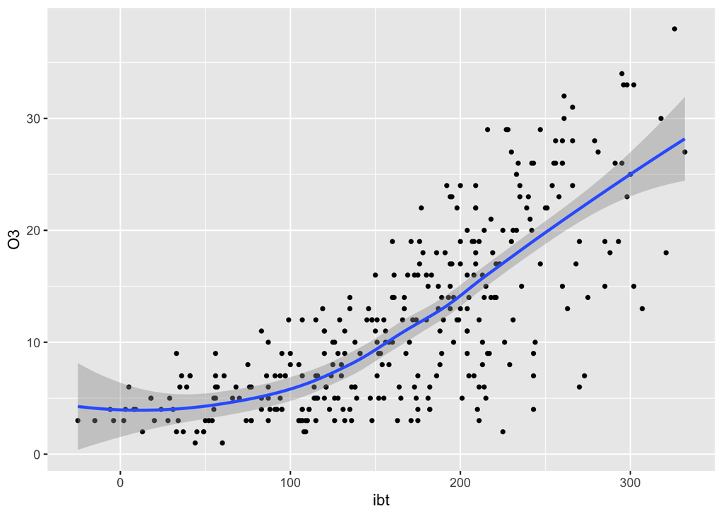

```r
ozone %>%
  ggplot(aes(x=ibt, y=O3)) +
  geom_point(size=1) +
  geom_smooth()
```

- An examination of the data reveals several nonlinear relationships indicating that a linear regression might not be appropriate without the addition of some transformation.

## Fit a regression tree

```r
library(rpart)
(tmod <- rpart(O3 ~ ., ozone))
```

```
## n= 330
##
## node), split, n, deviance, yval
##       * denotes terminal node
##
##  1) root 330 21115.4100 11.775760
##    2) temp< 67.5 214  4114.3040  7.425234
##      4) ibh>=3573.5 108   689.6296  5.148148 *
##      5) ibh< 3573.5 106  2294.1230  9.745283
##       10) dpg< -9.5 35   362.6857  6.457143 *
##       11) dpg>=-9.5 71  1366.4790 11.366200
##         22) ibt< 159 40   287.9000  9.050000 *
##         23) ibt>=159 31   587.0968 14.354840 *
##    3) temp>=67.5 116  5478.4400 19.801720
##      6) ibt< 226.5 55  1276.8360 15.945450
##       12) humidity< 59.5 10   167.6000 10.800000 *
##       13) humidity>=59.5 45   785.6444 17.088890 *
##      7) ibt>=226.5 61  2646.2620 23.278690
##       14) doy>=306.5 8   398.0000 16.000000 *
##       15) doy< 306.5 53  1760.4530 24.377360
##         30) vis>=55 36  1149.8890 22.944440 *
##         31) vis< 55 17   380.1176 27.411760 *
```

- The first split (nodes 2 and 3) is on temperature:
  - 214 observations have temperatures less than 67.5 with a mean response value of $7.4$.
  - 116 observations have temperatures greater than 67.5 with a mean response value of $20$.
- The total RSS has been reduced from $21115.00$ to $4114.30 + 5478.40 = 9592.70$.

More substantial output

```r
summary(tmod)
```

[output not shown]

Graphical displays

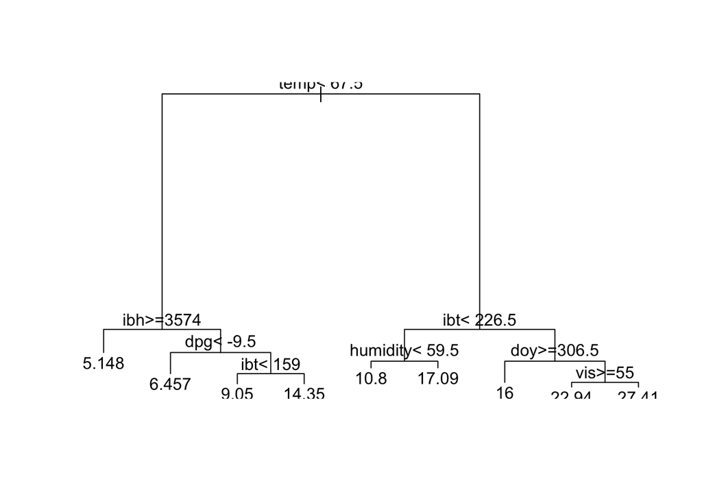

```r
plot(tmod)
text(tmod)
```

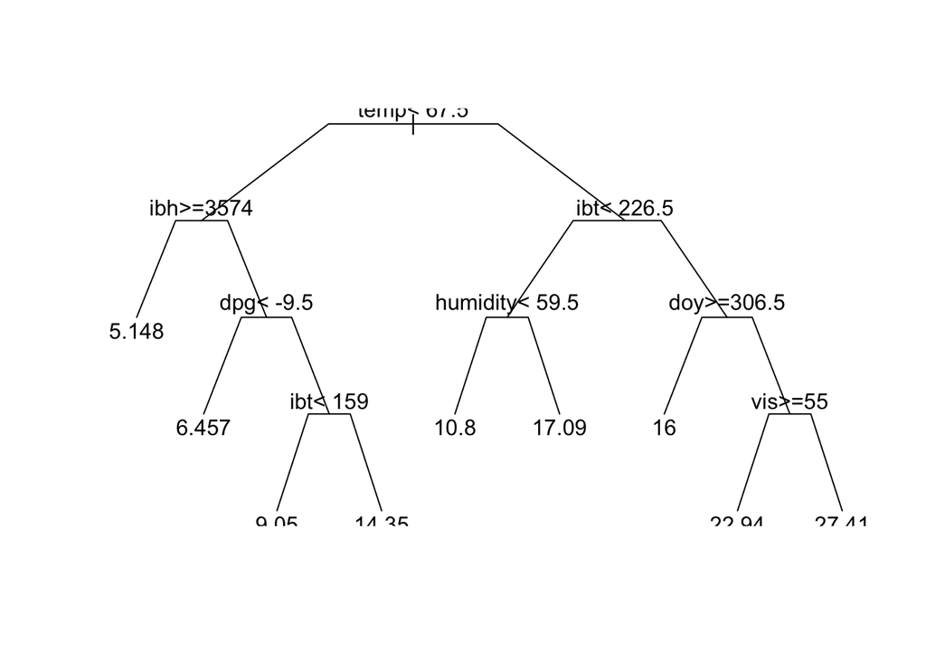

```r
plot(tmod,compress=T,uniform=T,branch=0.4)
text(tmod)
```

```r
library(rpart.plot)
rpart.plot(tmod, type = 2)
```

[output not shown]

## Recursive partitioning regression algorithm

1. Consider all partitions of the region of the predictors into two regions parallel to one of the axes. $N-1$ possible partitions for each predictor with a total of $(N-1)p$ partitions.
2. For each partition, take the mean of the responses in the partition and compute residual sum of squares (RSS). Pick the partition that minimizes the RSS among all available partitions.
   $$RSS(partition) = RSS(part_1) + RSS(part_2) = \sum_{y_i \in part_1} (y_i - \bar y_{part_1})^2 + \sum_{y_j \in part_2} (y_j - \bar y_{part_2})^2$$
3. Sub-partition the partitions in a recursive manner.
- For categorical predictors with $L$ levels:
  - $L-1$ possible splits for an ordered factor
  - $2^{L-1} - 1$ possible splits for an unordered factor
- Monotonely transforming a quantitative predictor makes no difference.
- Transforming response will make a difference because of the computation of RSS.
- Easy interpretation

## Missing values

When training, we may simply exclude points with missing values provided we weight appropriately.

If we believe being missing expresses some information, then

- for categorical predictor, assign an additional factor for missing values
- for continuous predictors, could discretize data into ranges so that missing value becomes an additional factor

When predict the response for a new value with missing values

- drop the prediction down through the tree until the missing values prevent us from going further
- use the mean value for the internal node to proceed

## Diagonostics

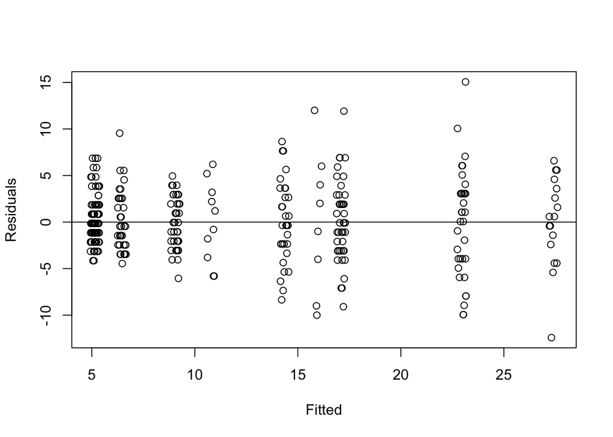

```r
plot(jitter(predict(tmod)),residuals(tmod),xlab="Fitted",ylab="Residuals")
abline(h=0)
```

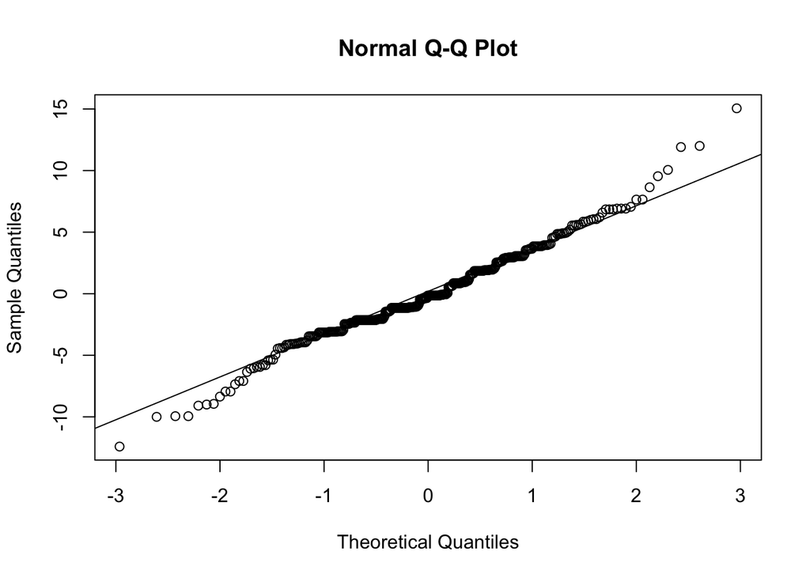

```r
qqnorm(residuals(tmod))
qqline(residuals(tmod))
```

## Prediction

Let’s predict the response for a new value, using the median value as an example

```r
(x0 <- apply(ozone[,-1], 2, median))
```

```
##       vh     wind humidity     temp      ibh      dpg      ibt      vis
##   5760.0      5.0     64.0     62.0   2112.5     24.0    167.5    120.0
##      doy
##    205.5
```

```r
rpart.plot(tmod, type = 2)
```

[output not shown]

```r
predict(tmod,data.frame(t(x0)))
```

```
##        1
## 14.35484
```

## Tree pruning

- The recursive partitioning algorithm describes how to grow the tree.
- How to decide the optimal size for the tree?
- *Greedy strategy*
  - keep partitioning until the reduction in overall cost (RSS) is not reduced by more than $\epsilon$.
  - can be difficult to set $\epsilon$ value.
- *Cross-validation* for more general model selection
  - *leave one out*: For a given tree, leave out one observation, recalculate the tree and predict the left-over observation. Repeat for all observations
  - $\sum_{j=1}^n (y_j - \hat f_{(j)}(x_j))^2$ where $\hat f_{(j)}$ denotes the predicted value of input $x_j$ given the tree given built without $x_j$
  - k-fold cross-validation randomly divide the data into k equal parts and use $k-1$ parts to predict the cases in the remaining part. k = 10 is typical choice.
- *Cost-complexity function* for trees further narrow down the set of trees worth validating

  $$CC(Tree) = \sum_{\mbox{terminal nodes: i}} RSS_i + \lambda(\mbox{number of terminal nodes})$$
  - large $\lambda$ value favous small trees
- Pruning the tree
  - use `cp` (ratio of $\lambda$ to $RSS$ of the root tree) to get a large tree

  ```r
  set.seed(7360)
  tmode <- rpart(O3 ~ ., ozone, cp = 0.001)
  printcp(tmode)
  ```

  ```
  ##
  ## Regression tree:
  ## rpart(formula = O3 ~ ., data = ozone, cp = 0.001)
  ##
  ## Variables actually used in tree construction:
  ## [1] doy      dpg      humidity ibh      ibt      temp     vh       vis
  ##
  ## Root node error: 21115/330 = 63.986
  ##
  ## n= 330
  ##
  ##           CP nsplit rel error  xerror     xstd
  ## 1  0.5456993      0   1.00000 1.00649 0.076959
  ## 2  0.0736591      1   0.45430 0.47756 0.041641
  ## 3  0.0535415      2   0.38064 0.43818 0.041663
  ## 4  0.0267557      3   0.32710 0.37264 0.035315
  ## 5  0.0232760      4   0.30034 0.37593 0.036334
  ## 6  0.0231021      5   0.27707 0.36501 0.035956
  ## 7  0.0153249      6   0.25397 0.35679 0.036236
  ## 8  0.0109137      7   0.23864 0.33960 0.033392
  ## 9  0.0070746      8   0.22773 0.32130 0.031940
  ## 10 0.0059918      9   0.22065 0.33369 0.034103
  ## 11 0.0059317     10   0.21466 0.33474 0.034161
  ## 12 0.0049709     12   0.20280 0.33863 0.034415
  ## 13 0.0047996     15   0.18789 0.34231 0.034722
  ## 14 0.0044712     16   0.18309 0.34201 0.034777
  ## 15 0.0031921     17   0.17861 0.34212 0.034971
  ## 16 0.0022152     19   0.17223 0.34343 0.035302
  ## 17 0.0020733     20   0.17002 0.34959 0.035899
  ## 18 0.0020297     22   0.16587 0.35026 0.035914
  ## 19 0.0014432     23   0.16384 0.34650 0.035938
  ## 20 0.0011322     24   0.16240 0.34717 0.035987
  ## 21 0.0011035     25   0.16126 0.34622 0.036007
  ## 22 0.0010000     26   0.16016 0.34534 0.036015
  ```

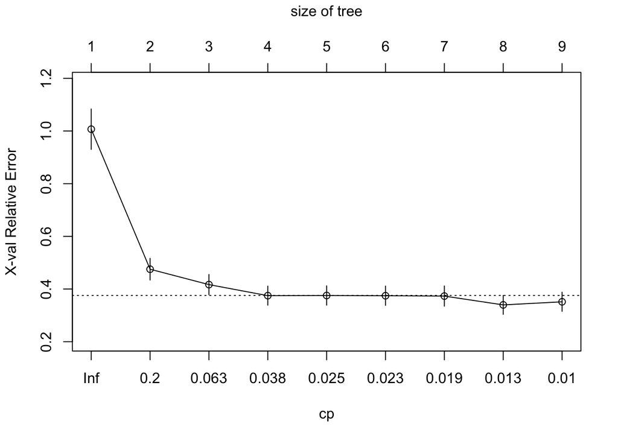

  ```r
  plotcp(tmod)
  ```

  ```r
  tmodr <- prune.rpart(tmod, 0.0153249)
  1-sum(residuals(tmodr)^2)/sum((ozone$O3-mean(ozone$O3))^2)
  ```

  ```
  ## [1] 0.7613586
  ```

  - Compare to a linear regression with 6 parameters

  ```r
  alm <- lm(O3 ~ vis + doy + ibt + humidity + temp, data = ozone)
  summary(alm)
  ```

  ```
  ##
  ## Call:
  ## lm(formula = O3 ~ vis + doy + ibt + humidity + temp, data = ozone)
  ##
  ## Residuals:
  ##      Min       1Q   Median       3Q      Max
  ## -12.2499  -3.0600  -0.1662   2.8773  13.2690
  ##
  ## Coefficients:
  ##               Estimate Std. Error t value Pr(>|t|)
  ## (Intercept) -10.017861   1.653058  -6.060 3.78e-09 ***
  ## vis          -0.008201   0.003692  -2.221    0.027 *
  ## doy          -0.010197   0.002445  -4.170 3.91e-05 ***
  ## ibt           0.034913   0.006707   5.205 3.45e-07 ***
  ## humidity      0.085101   0.014347   5.931 7.70e-09 ***
  ## temp          0.232806   0.036074   6.454 3.98e-10 ***
  ## ---
  ## Signif. codes:  0 '***' 0.001 '**' 0.01 '*' 0.05 '.' 0.1 ' ' 1
  ##
  ## Residual standard error: 4.43 on 324 degrees of freedom
  ## Multiple R-squared:  0.6988, Adjusted R-squared:  0.6942
  ## F-statistic: 150.3 on 5 and 324 DF,  p-value: < 2.2e-16
  ```

- Tree models are not optimal for prediction or explanation purposes.

## Random Forests

- A method that builds on trees to form a forest
- *Random forest* method uses bootstrap aggregating (known as *bagging*). For $b=1, \dots, B$
  - Draw a sample with replacement from ($X$, $Y$) to generate ($X_b$, $Y_b$)
  - fit a regression tree to ($X_b$, $Y_b$)
  - For cases not drawn in bootstrap sample, compute the mean squared error of prediction
- The $B$ trees form the forest. New predictions can be made by feeding predictor value into each tree and average the predictions.
- Subsample predictors at each node to reduce the correlations among the trees.
  - Default choice of subsample size is $\sqrt{p}$

### Fit a random forest

```r
library(randomForest)
fmod <- randomForest(O3 ~ ., ozone)
```

- plot the mean squared error (MSE) of prediction as number of trees $B$ increases

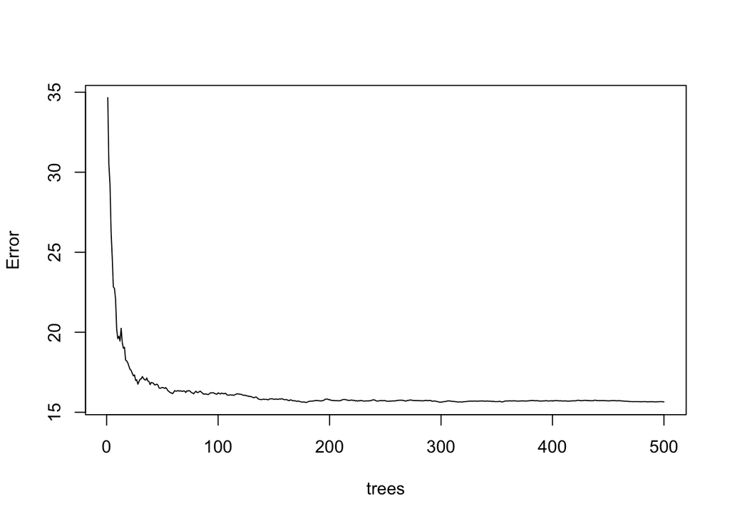

```r
plot(fmod, main = "")
```

- Use cross-validation
  - start with full sample $p = 9$
  - move on to $step \times p$ recursively, rounding at each stage
  - pick up best `nvars` for `mtry`

```r
cvr <- rfcv(ozone[,-1],ozone[,1],step=0.9)
cbind(nvars=cvr$n.var,MSE=cvr$error.cv)
```

```
##   nvars      MSE
## 9     9 16.11308
## 8     8 15.69783
## 7     7 15.90903
## 6     6 16.63753
## 5     5 17.39111
## 4     4 19.38641
## 3     3 20.93230
## 2     2 22.45007
## 1     1 25.87572
```

```r
fmod <- randomForest(O3 ~ ., ozone, mtry=9)
1-sum((fmod$predict-ozone$O3)^2)/sum((ozone$O3-mean(ozone$O3))^2)
```

```
## [1] 0.7410042
```

- *partial dependence plot* compute the predicted value for every case in the dataset excluding the predictor of interest and average over the predicted values

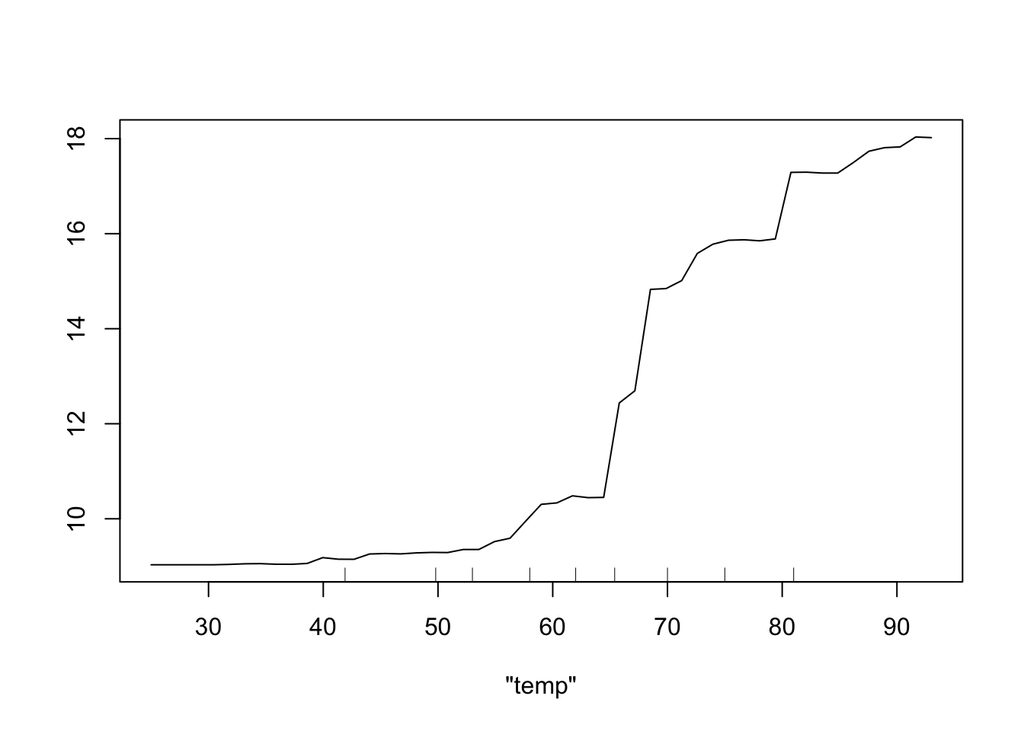

```r
partialPlot(fmod, ozone, "temp", main="")
```

- A measure of importance over predictors

```r
importance(fmod)
```

```
##          IncNodePurity
## vh            362.1073
## wind          184.8538
## humidity      865.7341
## temp        13023.4729
## ibh          1402.9185
## dpg           998.6239
## ibt          2566.1016
## vis           717.1797
## doy           806.5832
```

## Classification trees

- Responses are categorical
- A split should divide the observations within a node so that class types within a split are mostly of one kind
- Let $n_{ik}$ be the number of observations of type $k$ within terminal node $i$ and $p_{ik}$ be the observed proportion of type $k$ within node $i$.
- Several measure of *purity* of the node:
  - Deviance:

  $$D_i = -2 \sum_{k}n_{ik}\log p_{ik}$$
  - Entropy:

  $$D_i = - \sum_{k} p_{ik} \log p_{ik}$$
  - Gini index:

  $$D_i = 1 - \sum_k p_{ik}^2$$
- All measures are minimized when all members of the node are of the same type

### Kangaroo data

Identification of the sex and species of an historical specimen of kangaroo (`kanga` dataset in faraway package).

- Three possible species: *Giganteus*, *Melanops* and *Fuliginosus*
- The sex of the animal
- 18 skull measurements

We form separate trees for identifying the sex and species.

- read in data

```r
data(kanga, package="faraway")
x0 <- c(1115,NA,748,182,NA,NA,178,311,756,226,NA,NA,NA,48,1009,NA,204,593)
```

- exclude all variables that are missing in the test case

```r
kanga <- kanga[,c(T,F,!is.na(x0))]
kanga[1:2,]
```

```
##     species basilar.length palate.length palate.width squamosal.depth
## 1 giganteus           1312           882           NA             180
## 2 giganteus           1439           985          230             150
##   lacrymal.width zygomatic.width orbital.width foramina.length mandible.length
## 1            394             782           249              88            1086
## 2            416             824           233             100            1158
##   mandible.depth ramus.height
## 1            179          591
## 2            181          643
```

- First, look at missing values in the training set

```r
apply(kanga,2,function(x) sum(is.na(x)))
```

```
##         species  basilar.length   palate.length    palate.width squamosal.depth
##               0               1               1              24               1
##  lacrymal.width zygomatic.width   orbital.width foramina.length mandible.length
##               0               1               0               0              12
##  mandible.depth    ramus.height
##               0               0
```

- Compute the pairwise correlation of these variables with other variables

```r
round(cor(kanga[,-1],use="pairwise.complete.obs")[,c(3,9)],2)
```

```
##                 palate.width mandible.length
## basilar.length          0.77            0.98
## palate.length           0.81            0.98
## palate.width            1.00            0.81
## squamosal.depth         0.69            0.80
## lacrymal.width          0.77            0.92
## zygomatic.width         0.78            0.92
## orbital.width           0.12            0.25
## foramina.length         0.19            0.23
## mandible.length         0.81            1.00
## mandible.depth          0.62            0.85
## ramus.height            0.73            0.94
```

- Remove the two variables and remaining missing cases

```r
newko <- na.omit(kanga[,-c(4,10)])
dim(newko)
```

```
## [1] 144  10
```

- visualize the class separation over the two variables

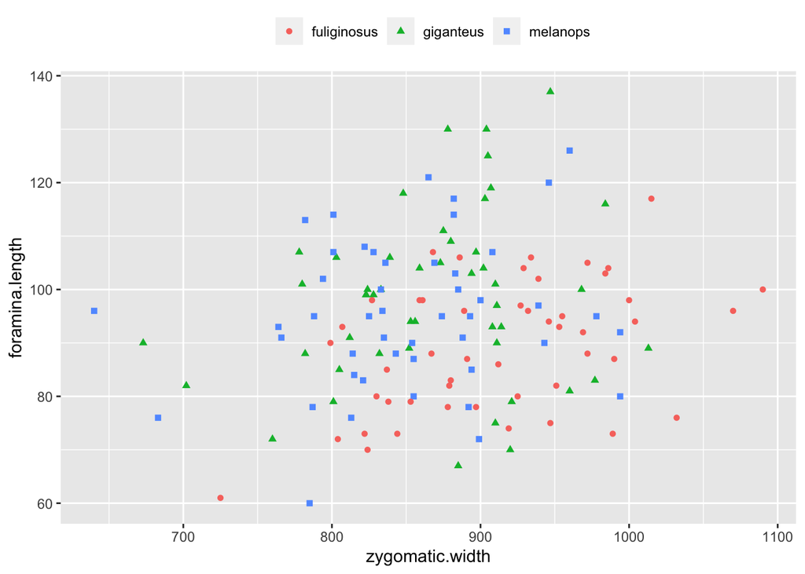

```r
ggplot(newko, aes(x=zygomatic.width,y=foramina.length,shape=species, color = species)) +
  geom_point() +
  theme(legend.position = "top", legend.direction ="horizontal", legend.title=element_blank())
```

### Fit a classification tree

- Gini’s index is the default choice of criterion

```r
set.seed(123)  # try with 7360
kt <- rpart(species ~ ., data=newko,control = rpart.control(cp = 0.001))
printcp(kt)
```

```
##
## Classification tree:
## rpart(formula = species ~ ., data = newko, control = rpart.control(cp = 0.001))
##
## Variables actually used in tree construction:
## [1] basilar.length  foramina.length lacrymal.width  ramus.height
## [5] squamosal.depth zygomatic.width
##
## Root node error: 95/144 = 0.65972
##
## n= 144
##
##         CP nsplit rel error  xerror     xstd
## 1 0.178947      0   1.00000 1.10526 0.056133
## 2 0.105263      1   0.82105 0.92632 0.061579
## 3 0.050000      2   0.71579 0.90526 0.061952
## 4 0.021053      6   0.51579 0.82105 0.062938
## 5 0.010526      7   0.49474 0.83158 0.062859
## 6 0.001000      8   0.48421 0.89474 0.062120
```

- Select the six-split tree and plot

```r
(ktp <- prune(kt,cp=0.0211))
```

```
## n= 144
##
## node), split, n, loss, yval, (yprob)
##       * denotes terminal node
##
##  1) root 144 95 fuliginosus (0.34027778 0.33333333 0.32638889)
##    2) zygomatic.width>=923 37 13 fuliginosus (0.64864865 0.16216216 0.18918919) *
##    3) zygomatic.width< 923 107 65 giganteus (0.23364486 0.39252336 0.37383178)
##      6) zygomatic.width>=901 16  3 giganteus (0.12500000 0.81250000 0.06250000) *
##      7) zygomatic.width< 901 91 52 melanops (0.25274725 0.31868132 0.42857143)
##       14) foramina.length< 98.5 58 33 melanops (0.36206897 0.20689655 0.43103448)
##         28) lacrymal.width< 448.5 50 29 fuliginosus (0.42000000 0.24000000 0.34000000)
##           56) ramus.height>=628.5 33 14 fuliginosus (0.57575758 0.18181818 0.24242424) *
##           57) ramus.height< 628.5 17  8 melanops (0.11764706 0.35294118 0.52941176) *
##         29) lacrymal.width>=448.5 8  0 melanops (0.00000000 0.00000000 1.00000000) *
##       15) foramina.length>=98.5 33 16 giganteus (0.06060606 0.51515152 0.42424242)
##         30) squamosal.depth< 182.5 26 10 giganteus (0.07692308 0.61538462 0.30769231) *
##         31) squamosal.depth>=182.5 7  1 melanops (0.00000000 0.14285714 0.85714286) *
```

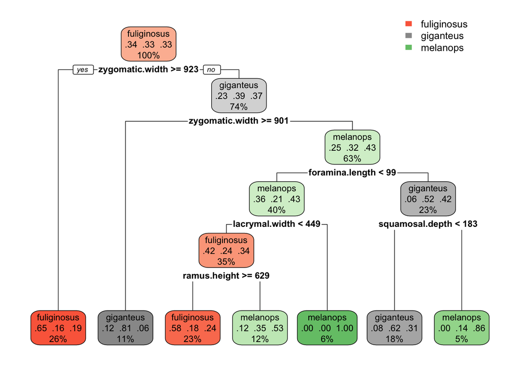

```r
rpart.plot(ktp, type = 2)
```

- Compute the misclassification error

```r
 (tt <- table(actual=newko$species, predicted=predict(ktp, type="class")))
```

```
##              predicted
## actual        fuliginosus giganteus melanops
##   fuliginosus          43         4        2
##   giganteus            12        29        7
##   melanops             15         9       23
```

```r
1-sum(diag(tt))/sum(tt)
```

```
## [1] 0.3402778
```

- May instead use the Principle components for constructing the tree for lower error rate (0.25)

## Classification using forests

- A natural extension to classification trees

```r
cvr <- rfcv(newko[,-1],newko[,1],step=0.9)
cbind(nvars=cvr$n.var,error.rate=cvr$error.cv)
```

```
##   nvars error.rate
## 9     9  0.5138889
## 8     8  0.4652778
## 7     7  0.4722222
## 6     6  0.4722222
## 5     5  0.4791667
## 4     4  0.5208333
## 3     3  0.5763889
## 2     2  0.5694444
## 1     1  0.5833333
```

```r
fmod <- randomForest(species ~ ., newko, mtry=6)
(tt <- table(actual=newko$species,predicted=predict(fmod)))
```

```
##              predicted
## actual        fuliginosus giganteus melanops
##   fuliginosus          37         5        7
##   giganteus             5        21       22
##   melanops             11        20       16
```

```r
1-sum(diag(tt))/sum(tt)
```

```
## [1] 0.4861111
```

Use principal components on the predictors for rescue

```r
pck <- princomp(newko[,-1])
pcdf <- data.frame(species = newko$species, pck$scores)
fmod <- randomForest(species ~ ., pcdf, mtry=6)
tt <- table(actual = newko$species, predicted=predict(fmod))
1-sum(diag(tt))/sum(tt)
```

```
## [1] 0.3541667
```